```r
require(tidyverse)
```

In protocol 6 we have seen how many time traces can be visualized with a heatmap style data visualization. The advantage is that huge amounts of data can be simultaneously visualized. However, it is difficult to relate the color to numbers. As such the color coded values in a heatmap give a qualitative view of heterogeneity. In this protocol, we use a method that allows more data than an ordinary lineplot, but keeps the advantage of this plot, i.e. allowing a quantitative comparison. To do this, an offset between curves is introduced. A package to this directly in ggplot2 is available (`ggridges`) but it may not work well when the values show a negative and positive deviation from baseline values (usually the baseline is zero). In addition, we have more flexibility (and insight) when we do this ourselves. Read the data

```r
df1 <- read.csv("Rac_S1P.csv")
```

Make tidy

```r
df_tidy <- pivot_longer(df1, cols = -c(Time), names_to = "Cell", values_to = "Activity")
```

```r
df_rank <- df_tidy %>% group_by(Cell) %>% filter(Time>=2 & Time <=10) %>% summarise(amplitude=sum(Activity)) %>% mutate(rank=percent_rank(amplitude))
```

Add rank to the df_tidy dataframe

```r
df_tidy <- as.data.frame(full_join(df_tidy, df_rank,by="Cell"))
```

Define the plot

```r
p <- ggplot(df_tidy, aes(x=Time+(rank*10), y=(Activity+(rank*1)), group=Cell))
```

Ucomment for no shift x-axis p <- ggplot(df_tidy, aes(x=Time, y=Ratio+(rank*1), group=Cell, height = rank)) Add the data as lines

```r
p <- p + geom_line(alpha=0.5, size=0.5)
```

p <- p + annotate(“segment”, x = 0, xend = 20, y = 1, yend = 3, size=.5, color=“grey50”) + annotate(“segment”, x = 0, xend = 20, y = 1, yend = 1, size=.5, color=“grey50”) + annotate(“segment”, x = 20, xend = 40, y = 1, yend = 3, size=.5, color=“grey50”) Add labels:

```r
p <-
  p + labs(
    title = "Activities measured in single cells over time",
    subtitle = "Sorting of the cells is based on integrated activity",
    x = "Time [min]",
    y = "Activity [arbitrary units]",
    caption = "(based on data from Reinhard: xxxx)",
    tag = "Protocol 7"
  )
```

Uncomment to add color p <- p+ geom_line(aes(color=as.factor(rank))) Format layout

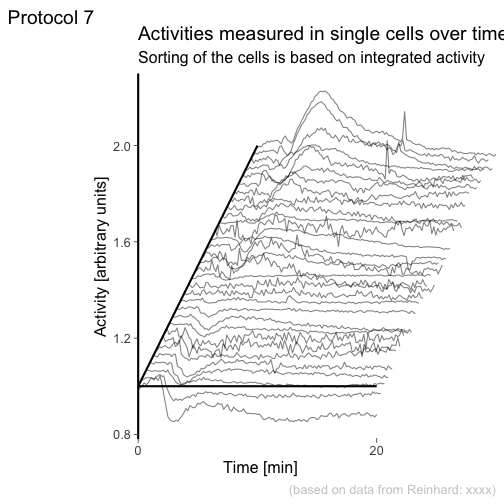

```r
p <- p + theme_classic(base_size = 16)
p <- p + theme(panel.grid.major = element_blank(),
               plot.caption = element_text(color = "grey80"),
           panel.grid.minor = element_blank(),
           axis.line.x = element_blank(),
           axis.title.x = element_text(hjust = 0.3),
           NULL)

p <- p + annotate(geom = "segment", x=0,y=1,xend=10,yend=2, size=1)
p <- p + annotate(geom = "segment", x=0,y=1,xend=20,yend=1, size=1)

p + scale_x_continuous(breaks = c(0,20), expand = c(0, 0))
```